# Corso-multivariate-models.R

juliannacorso

2023-02-28

title: HW4 author: Julianna output: html_documemnt

Import data

```r
library(vegan)
data(dune)
data(dune.env)
?dune
```

1. Conduct an indirect ordination on the dune plant community. Specifically, visually examine a NMDS plot using the bray-curtis distance metric. Below is some code to help you develop a potential plot that emphasizes the role of the environmental variable “Moisture”. Describe how you interpret the graphic. What is the goal of creating such a plot? Does this analysis suggest any interesting findings with respect to the dune vegetation?

```r
dune_mds <- metaMDS(dune,trace=0)
dune_mds
```

```
##
## Call:
## metaMDS(comm = dune, trace = 0)
##
## global Multidimensional Scaling using monoMDS
##
## Data:     dune
## Distance: bray
##
## Dimensions: 2
## Stress:     0.1183186
## Stress type 1, weak ties
## Best solution was repeated 1 time in 20 tries
## The best solution was from try 17 (random start)
## Scaling: centring, PC rotation, halfchange scaling
## Species: expanded scores based on 'dune'
```

```r
dune_fit <- envfit(dune_mds, dune.env)
dune_fit
```

```
##
## ***VECTORS
##
##      NMDS1   NMDS2     r2 Pr(>r)
## A1 0.96474 0.26320 0.3649  0.027 *
## ---
## Signif. codes:  0 '***' 0.001 '**' 0.01 '*' 0.05 '.' 0.1 ' ' 1
## Permutation: free
## Number of permutations: 999
##
## ***FACTORS:
##
## Centroids:
##                NMDS1   NMDS2
## Moisture1    -0.5101 -0.0403
## Moisture2    -0.3938  0.0139
## Moisture4     0.2765 -0.4033
## Moisture5     0.6561  0.1476
## ManagementBF -0.4534 -0.0102
## ManagementHF -0.2636 -0.1282
## ManagementNM  0.2958  0.5790
## ManagementSF  0.1506 -0.4670
## UseHayfield  -0.1568  0.3248
## UseHaypastu  -0.0412 -0.3370
## UsePasture    0.2854  0.0844
## Manure0       0.2958  0.5790
## Manure1      -0.2482 -0.0215
## Manure2      -0.3079 -0.1866
## Manure3       0.3101 -0.2470
## Manure4      -0.3463 -0.5582
##
## Goodness of fit:
##                r2 Pr(>r)
## Moisture   0.5014  0.002 **
## Management 0.4134  0.005 **
## Use        0.1871  0.105
## Manure     0.4247  0.020 *
## ---
## Signif. codes:  0 '***' 0.001 '**' 0.01 '*' 0.05 '.' 0.1 ' ' 1
## Permutation: free
## Number of permutations: 999
```

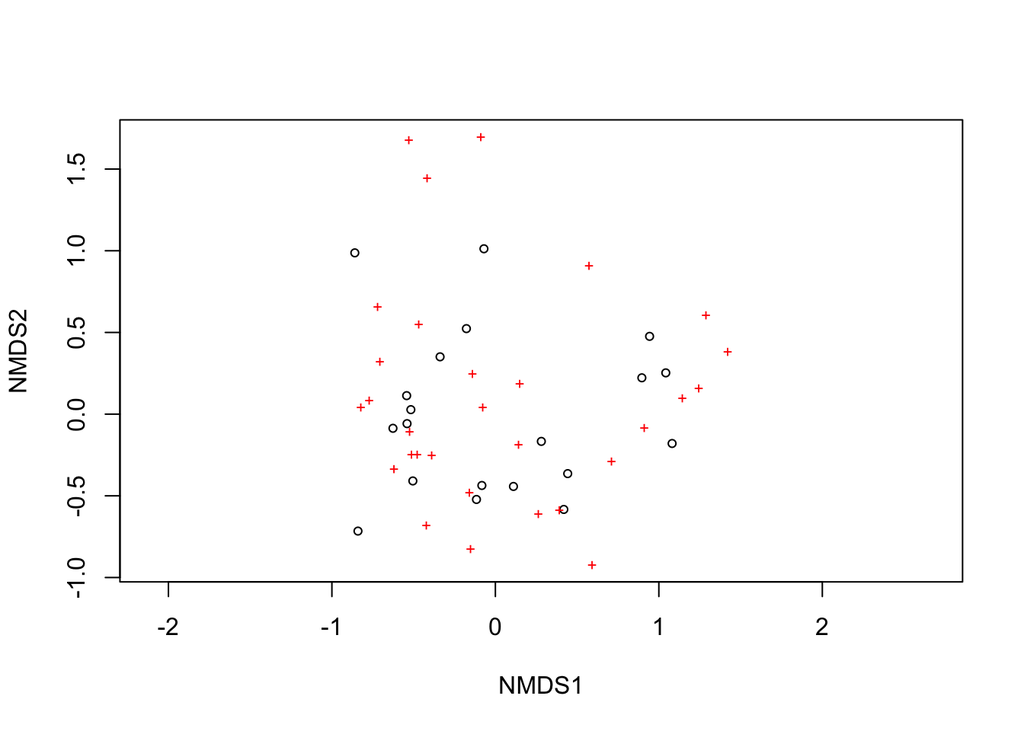

```r
plot(dune_mds)
```

code to help with plot from assignment

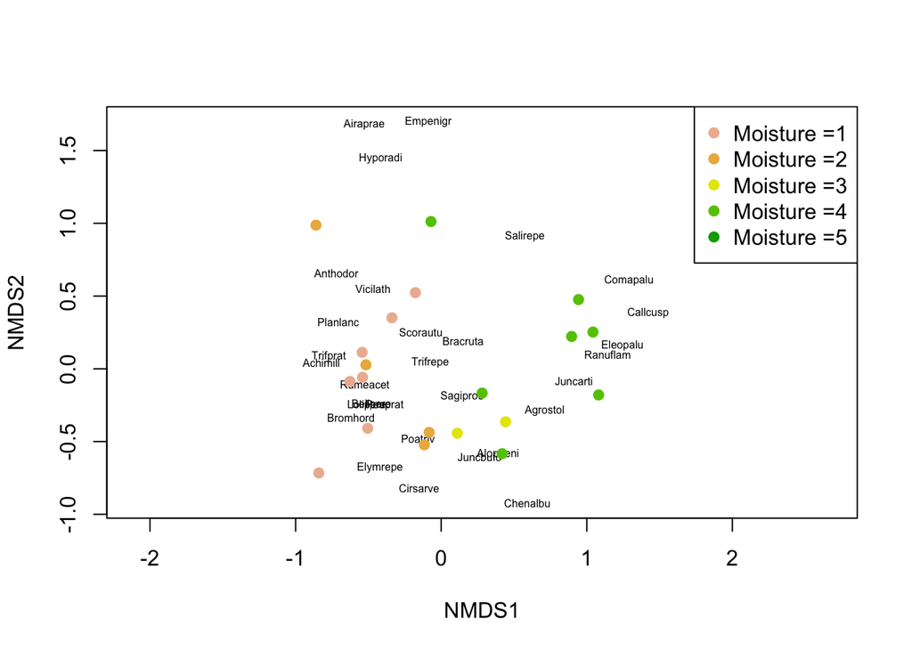

```r
plot(dune_mds, type='n')
text(dune_mds, 'sp', cex=.5)
# generate vector of colors
color_vect = rev(terrain.colors(6))[-1]
points(dune_mds, 'sites', pch=19,
       col=color_vect[dune.env$Moisture])
legend('topright', paste("Moisture =", 1:5, sep=''),
       col=color_vect, pch=19)
```

treating moisture as a numeric variable instead of a factor with numerous centroids

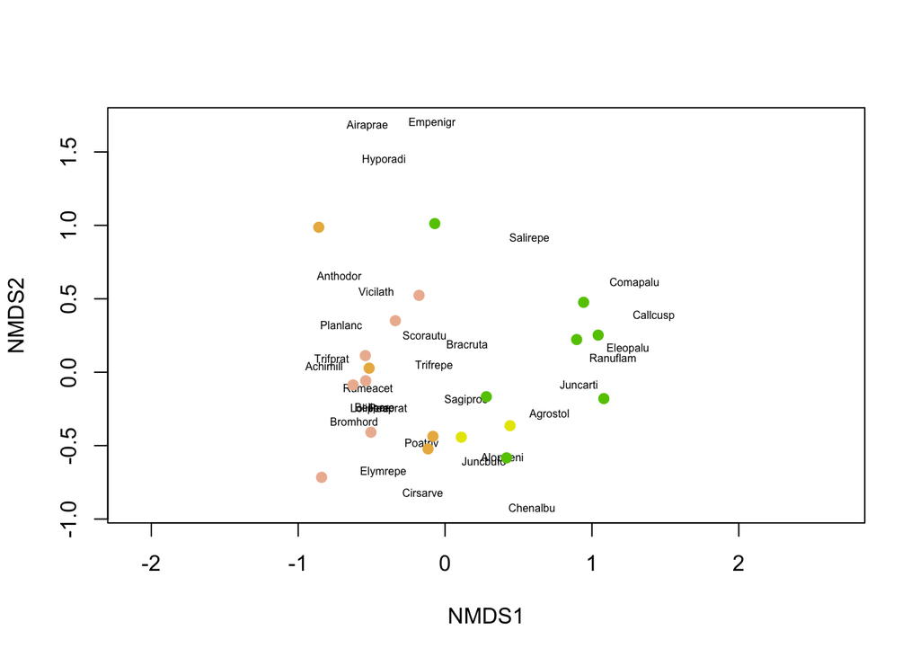

```r
plot(dune_mds, type='n')
text(dune_mds, 'sp', cex=.5)
# generate vector of colors
color_vect = rev(terrain.colors(6))[-1]
points(dune_mds, 'sites', pch=19,
       col=color_vect[as.numeric(dune.env$Moisture)])
legend('topright', "Moisture", col=color_vect, pch=19, bty = "n",
       title = "Moisture", inset = c(0,1), x.intersp = 0.5, y.intersp = 0.5)
```

Within this plot there is a pattern in the distribution of samples based on their MDS coordinates and moisture levels. There are clustering so samples, but the relationship between the MDS coordinates and moisture levels is not abundently clear from this plot alone. Further analysis such as cluster analysis or regression, would be needed to fully explore the relationship between these variables. 2. Carry out a direct ordination using CCA in order to test any potential hypotheses that you developed after examining the MDS plot. Specifically, carry out a test of the entire model (i.e., including all constrained axes) and also carry out tests at the scale of individual explanatory variables you included in your model if you included more than one variable. Plot your results.

Test all enviornmental variables

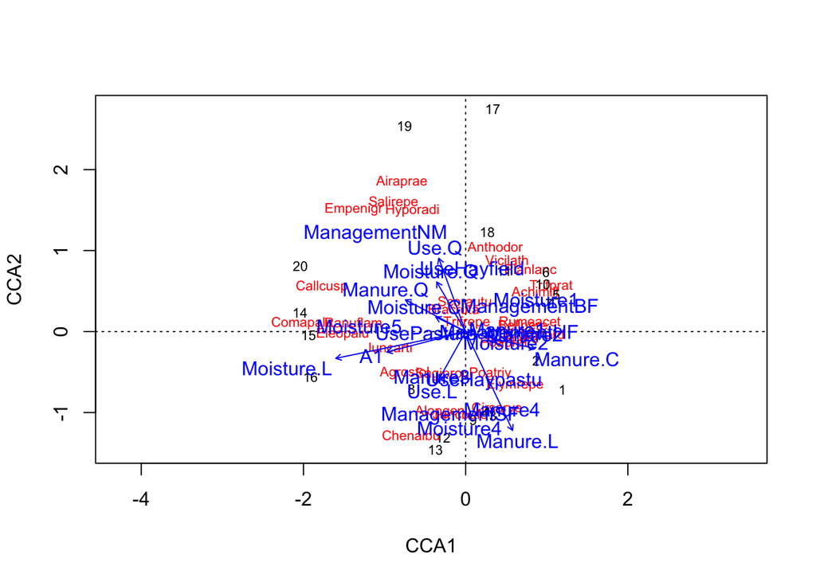

```r
dune_cca <- cca(dune~ A1 + Moisture + Management + Use + Manure, data=dune.env)
plot(dune_cca)
```

WOah Loading points without scores

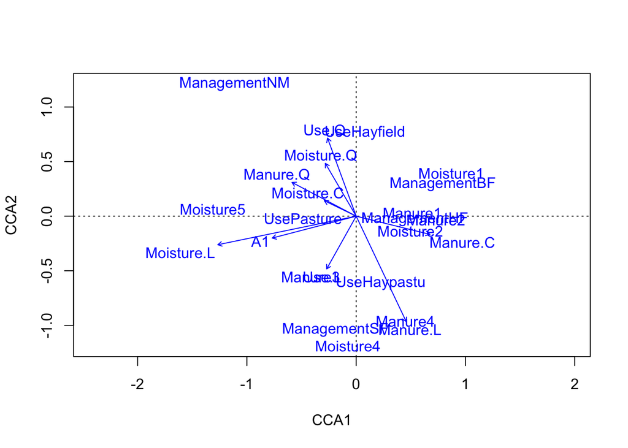

```r
plot(dune_cca, display= 'cn')
```

where scores are points and loadings are vectors

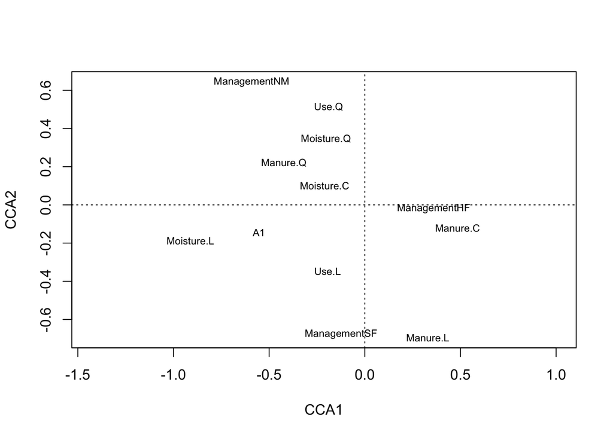

```r
plot(dune_cca, display= 'bp')
```

looking at data

```r
dune_cca
```

```
## Call: cca(formula = dune ~ A1 + Moisture + Management + Use + Manure,
## data = dune.env)
##
##               Inertia Proportion Rank
## Total          2.1153     1.0000
## Constrained    1.5032     0.7106   12
## Unconstrained  0.6121     0.2894    7
## Inertia is scaled Chi-square
## Some constraints or conditions were aliased because they were redundant
##
## Eigenvalues for constrained axes:
##   CCA1   CCA2   CCA3   CCA4   CCA5   CCA6   CCA7   CCA8   CCA9  CCA10  CCA11
## 0.4671 0.3410 0.1761 0.1532 0.0953 0.0703 0.0589 0.0499 0.0318 0.0260 0.0228
##  CCA12
## 0.0108
##
## Eigenvalues for unconstrained axes:
##     CA1     CA2     CA3     CA4     CA5     CA6     CA7
## 0.27237 0.10876 0.08975 0.06305 0.03489 0.02529 0.01798
```

So with all the paramiters in the data we get a value of 71%, but this is probably not very accurate as there are a lot of random variables that are being included. To find a more accurate calculation we should use the infamous rsquared

```r
dune_cca_adj <- RsquareAdj(dune_cca, nperm=5)
```

for more accurate reading run more then 5 times

```r
dune_cca_adj <- RsquareAdj(dune_cca, nperm=999)
dune_cca_adj
```

```
## $r.squared
## [1] 0.7106267
##
## $adj.r.squared
## [1] 0.2107215
```

Can run an anova

```r
anova(dune_cca)
```

```
## Permutation test for cca under reduced model
## Permutation: free
## Number of permutations: 999
##
## Model: cca(formula = dune ~ A1 + Moisture + Management + Use + Manure, data = dune.env)
##          Df ChiSquare      F Pr(>F)
## Model    12    1.5032 1.4325  0.035 *
## Residual  7    0.6121
## ---
## Signif. codes:  0 '***' 0.001 '**' 0.01 '*' 0.05 '.' 0.1 ' ' 1
```

Which can then be compared to anovas of each of the variables tested

Terms

```r
anova(dune_cca, by='terms')
```

```
## Permutation test for cca under reduced model
## Terms added sequentially (first to last)
## Permutation: free
## Number of permutations: 999
##
## Model: cca(formula = dune ~ A1 + Moisture + Management + Use + Manure, data = dune.env)
##            Df ChiSquare      F Pr(>F)
## A1          1   0.22476 2.5704  0.014 *
## Moisture    3   0.51898 1.9783  0.007 **
## Management  3   0.39543 1.5074  0.064 .
## Use         2   0.10910 0.6238  0.914
## Manure      3   0.25490 0.9717  0.516
## Residual    7   0.61210
## ---
## Signif. codes:  0 '***' 0.001 '**' 0.01 '*' 0.05 '.' 0.1 ' ' 1
```

Margin

```r
anova(dune_cca, by='margin')
```

```
## Permutation test for cca under reduced model
## Marginal effects of terms
## Permutation: free
## Number of permutations: 999
##
## Model: cca(formula = dune ~ A1 + Moisture + Management + Use + Manure, data = dune.env)
##            Df ChiSquare      F Pr(>F)
## A1          1   0.11070 1.2660  0.235
## Moisture    3   0.31587 1.2041  0.221
## Management  2   0.15882 0.9081  0.587
## Use         2   0.13010 0.7439  0.761
## Manure      3   0.25490 0.9717  0.509
## Residual    7   0.61210
```

Axis

```r
anova(dune_cca, by='axis')
```

```
## Permutation test for cca under reduced model
## Forward tests for axes
## Permutation: free
## Number of permutations: 999
##
## Model: cca(formula = dune ~ A1 + Moisture + Management + Use + Manure, data = dune.env)
##          Df ChiSquare      F Pr(>F)
## CCA1      1   0.46713 5.3422  0.033 *
## CCA2      1   0.34102 3.8999  0.250
## CCA3      1   0.17606 2.0135  0.905
## CCA4      1   0.15317 1.7516  0.944
## CCA5      1   0.09528 1.0896  0.999
## CCA6      1   0.07027 0.8036  1.000
## CCA7      1   0.05887 0.6732  1.000
## CCA8      1   0.04993 0.5710  1.000
## CCA9      1   0.03183 0.3640  1.000
## CCA10     1   0.02596 0.2969  1.000
## CCA11     1   0.02282 0.2610  0.997
## CCA12     1   0.01082 0.1237  0.996
## Residual  7   0.61210
## ---
## Signif. codes:  0 '***' 0.001 '**' 0.01 '*' 0.05 '.' 0.1 ' ' 1
```

Onedf

```r
anova(dune_cca, by='onedf')
```

```
## Permutation test for cca under reduced model
## Sequential test for contrasts
## Permutation: free
## Number of permutations: 999
##
## Model: cca(formula = dune ~ A1 + Moisture + Management + Use + Manure, data = dune.env)
##              Df ChiSquare      F Pr(>F)
## A1            1   0.22476 2.5704  0.009 **
## Moisture.L    1   0.31097 3.5562  0.002 **
## Moisture.Q    1   0.10328 1.1811  0.269
## Moisture.C    1   0.10473 1.1977  0.273
## ManagementHF  1   0.09403 1.0753  0.337
## ManagementNM  1   0.22017 2.5178  0.007 **
## ManagementSF  1   0.08124 0.9291  0.475
## Use.L         1   0.06958 0.7958  0.642
## Use.Q         1   0.03951 0.4519  0.953
## Manure.L      1   0.10324 1.1807  0.299
## Manure.Q      1   0.09582 1.0958  0.337
## Manure.C      1   0.05584 0.6386  0.836
## Residual      7   0.61210
## ---
## Signif. codes:  0 '***' 0.001 '**' 0.01 '*' 0.05 '.' 0.1 ' ' 1
```

with this information we can start to clean up the graph by taking out some of the variables. We see that Moisture and management and A1 have some significant values so lets keep that.

```r
dune_cca_2.0 <- cca(dune~ A1 + Moisture + Management, data=dune.env)
dune_cca_2.0
```

```
## Call: cca(formula = dune ~ A1 + Moisture + Management, data = dune.env)
##
##               Inertia Proportion Rank
## Total          2.1153     1.0000
## Constrained    1.1392     0.5385    7
## Unconstrained  0.9761     0.4615   12
## Inertia is scaled Chi-square
##
## Eigenvalues for constrained axes:
##   CCA1   CCA2   CCA3   CCA4   CCA5   CCA6   CCA7
## 0.4483 0.3001 0.1499 0.1073 0.0567 0.0434 0.0335
##
## Eigenvalues for unconstrained axes:
##     CA1     CA2     CA3     CA4     CA5     CA6     CA7     CA8     CA9    CA10
## 0.30637 0.13191 0.11516 0.10947 0.07724 0.07575 0.04871 0.03758 0.03106 0.02102
##    CA11    CA12
## 0.01254 0.00928
```

lets take the R^2 of that new one

```r
dune_cca_2.0_adj <- RsquareAdj(dune_cca_2.0, nperm=999)
dune_cca_2.0_adj
```

```
## $r.squared
## [1] 0.5385459
##
## $adj.r.squared
## [1] 0.26993
```

```r
anova(dune_cca_2.0)
```

```
## Permutation test for cca under reduced model
## Permutation: free
## Number of permutations: 999
##
## Model: cca(formula = dune ~ A1 + Moisture + Management, data = dune.env)
##          Df ChiSquare      F Pr(>F)
## Model     7    1.1392 2.0007  0.001 ***
## Residual 12    0.9761
## ---
## Signif. codes:  0 '***' 0.001 '**' 0.01 '*' 0.05 '.' 0.1 ' ' 1
```

A1 seems to have the smallest effect and then management less then moisture. So the data can be refined by removing A1 if desiered as well.

```r
anova(dune_cca_2.0, dune_cca)
```

```
## Permutation tests for cca under reduced model
## Permutation: free
## Number of permutations: 999
##
## Model 1: dune ~ A1 + Moisture + Management
## Model 2: dune ~ A1 + Moisture + Management + Use + Manure
##   ResDf ResChiSquare Df ChiSquare      F Pr(>F)
## 1    12       0.9761
## 2     7       0.6121  5     0.364 0.8325  0.758
```

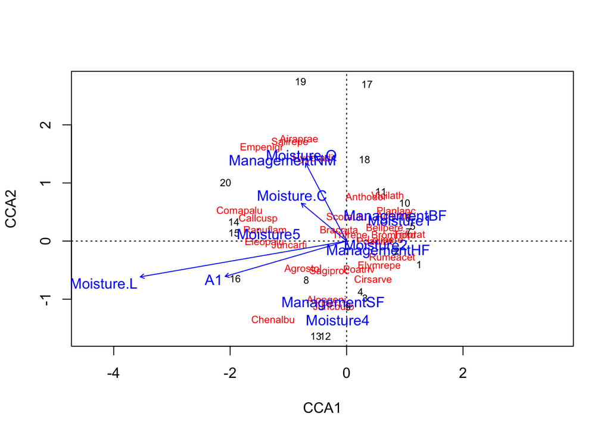

```r
plot(dune_cca_2.0)
```

3. Do your two analyses agree with one another or complement one another or do these two analyses seem to be suggesting different take home messages? Which analysis do you find to be more useful?

I prefer the CDS plot, although the NMDS explains the dominate axes of variation and not just that of the enviornment as shown in CDS. However the stright forward correlation that the CDS provides is easier to understand and desipher in plain language then the NMDS. Both are interesting to explore for the data set reguardless.